# Waveforms and plots

**Viewing waveforms and plotting signals**

Let’s make a capture to look at:

```julia
@encoding Phase begin IDLE; WARM; RUN end

@quartz struct Heater
  @in  go::Bool = false
  @out on::Bool
  phase::Phase = IDLE
  temp::Bits{8} = 0
end

@on Heater posedge(clk) begin
  @fsm phase begin
    @state IDLE
      go && (phase ← WARM)
    @state WARM
      temp ← temp + 3
      temp > 60 && (phase ← RUN)
    @state RUN
      temp ← temp - 1
      temp < 20 && (phase ← IDLE)
  end
  on ← phase == WARM
end

sim = Simulation(Heater(); clocks=(clk=1MHz,), watch="*")
out = @run sim begin
  advance_by(5µs)
  sim.go = true
  advance_by(1µs)
  sim.go = false
  advance_by(80µs)
end
```

## Plots

With `Plots` loaded, a signal plots as a step plot of the *wire* against time in seconds, with the ticks labelled in whatever unit suits the span: a one-bit lane is labelled `L` and `H`, a pin asserted low is drawn as the voltage on it — low while asserted — and an encoded register is labelled by state name:

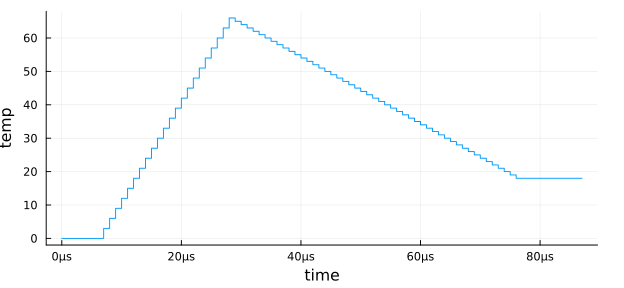

```julia
plot(out.temp)
```

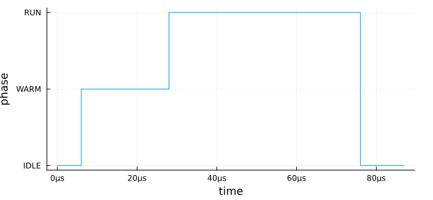

```julia
plot(out.phase)
```

`plot(out, "a", "b", ...)` stacks several nets as lanes:

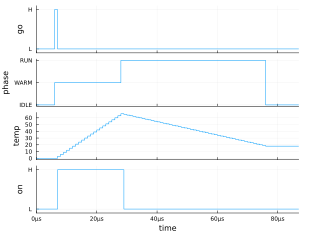

```julia
plot(out, "go", "phase", "temp", "on"; size=(650, 500))
```

## VCD and Surfer

`write("run.vcd", out, VCD())` writes the capture as a VCD file of the wires — real time on the axis, a pin asserted low inverted as a probe would see it, a lane per clock, and encoded registers written twice, as bits and as the state’s name, which viewers show as text. Any waveform viewer opens it.

[Surfer](https://surfer-project.org) is the one QuartzHDL talks to directly. With `surfer` on your path:

```julia
view(out)             # open the capture in Surfer
view(sim)             # a live view: refreshed after every @run, and during long ones
```

[figure not shown]

The `Heater` capture in Surfer: the clock, `go`, the phase by state name, `temp`, and `on`.

`view(Surfer(), x)` names the viewer explicitly. A viewer is an `IO`, so `write(Surfer(), out, VCD())` is the same thing, and `close(v)` closes it. The live view keeps its zoom and the signals you have added across refreshes, so a typical debugging loop is: open the view, `@run` a bit, look, `@run` a bit more.

## Signals as signals

`sampled(out.temp)` gives the net as one value per clock, and with [`SignalAnalysis.jl`](https://github.com/org-arl/SignalAnalysis.jl) loaded it has a frame rate, so the rest of that package’s tools — spectra, filters, `psd`, `specgram` — take it directly:

```julia
using SignalAnalysis

x = sampled(out.temp)
framerate(x), length(x)
```

```
(1.0e6, 87)
```

This is the step that makes porting a signal-processing algorithm pleasant: the hardware’s output is a signal like any other, and can be compared against the floating-point reference with the same tools.

## Next

Library components: the chips around the design.